# Презентация по Лабораторной работе No10

Операционные системы

Нджову Н.

Российский университет дружбы народов, Москва, Россия

11 АПРЕЛЯ 2024

## Цель работы

Познакомиться с операционной системой Linux. Получить практические навыки работы с редактором vi, установленным по умолчанию практически во всех дистрибутивах.

## Задание

1. Создание нового файла с использованием vi
2. Редактирование существующего файла

## 1. Создание нового файла с использованием vi

Я создайте каталог с именем ~/work/os/lab06 и перехожу в только созданный каталог(рис.1)

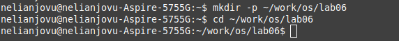

создание каталога

## 1. Создание нового файла с использованием vi

Я зову vi и создаю файл hello.sh. После этого я нажмаю клавишу i и вводите текст(рис.2)

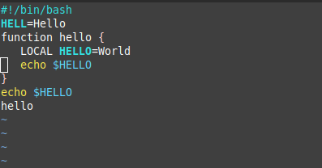

создание файла и выдение текста

## 1. Создание нового файла с использованием vi

Я меняю права доступа к файлу hello.sh, добавляя права выполнение у владельца(рис.4)

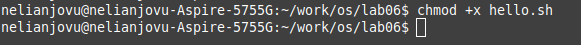

изменение правы доступа

## 2. Редактирование существующего файла

Я установливаю курсор в конец слова HELL второй строки(рис.6)

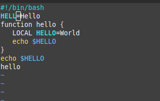

устанавление курсора в конец слова HELL

## 2. Редактирование существующего файла

Перехожу в режим вставки и замените на HELLO.Я нажмаю Esc для возврата в командный режим(рис.7)

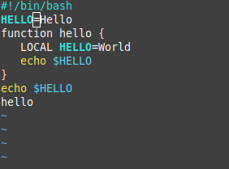

изменение HELL на HELLO

## 2. Редактирование существующего файла

Я установливаю курсор на четвертую строку и сотрите слово LOCAL(рис.8)

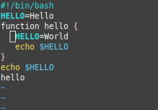

удаление LOCAL

## 2. Редактирование существующего файла

Я перехожу в режим вставки и наберите текст: local, после того нажмаю Esc для возврата в командный режим(рис.9)

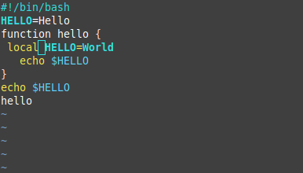

запись текста:local

## 2. Редактирование существующего файла

Я установливаю курсор на последней строке файла. Вставьте после неё строку, содержащую текст: echo $HELLO.После того нажмите Esc для перехода в командный режим(рис.10)

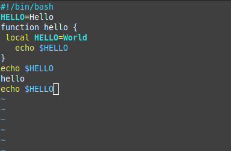

запись текста:echo $HELLO

## 2. Редактирование существующего файла

Я удаляю последнюю строку с помощью ‘d’ ‘w’(рис.11)

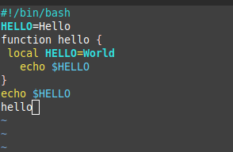

удаление текста

## 2. Редактирование существующего файла

Я введу команду отмены изменений “u” для отмены последней команды(рис.12)

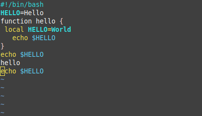

отмены изменений

## Выводы

Выполняя эту лабараторную работу познакомилася с операционной системой Linux. Получила практические навыки работы с редактором vi, установленным по умолчанию практически во всех дистрибутивах.